# ARIMA

Romanova

22 мая 2019 г

# 1 ARIMA

## 1.1 Реальные данные

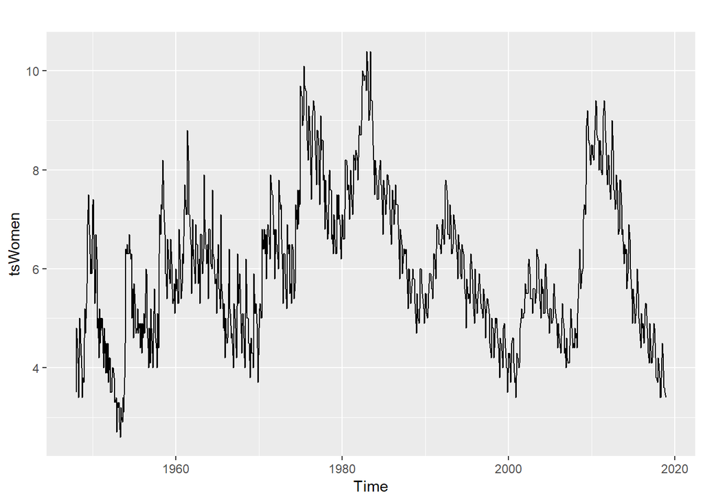

```r
tsWomen<-ts(TS.data$Value, frequency = 12, start = 1948)
autoplot(tsWomen)
```

Разобьем на тренировочную и тестовую выборки:

```r
Women.train<-ts(tsWomen[1:804],frequency = 12,start = 1948)
Women.test<-ts(tsWomen[805:852],frequency = 12,start = 2015)
```

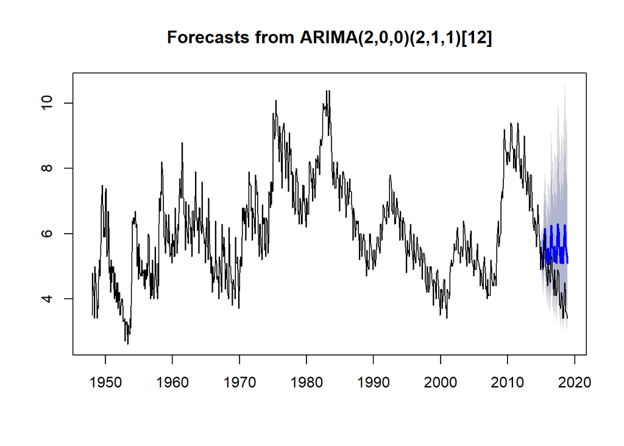

```r
fit.arima<-auto.arima(Women.train,trace = FALSE,
                         lambda = 0, stepwise = FALSE)
for.arima<-forecast::forecast(fit.arima,h=length(Women.test))
plot(for.arima)
lines(tsWomen)
```

Не очень впечатляюще.

# 2 SSA

Так как для прогноза нам может хватить меньшего количества компонент в сигнале, возможно, что-то получится и для нашего ряда (хотя в целом делать для него ssa за один раз – дело довольно гиблое).

Берем обрезанный ряд уровня женской безработицы. Объем тестовой выборки = 48 (то есть 4 года).

Возьмем длину окна 36.

```r
Women.ssa.short<-ssa(Women.train,L=36)
```

Как показали эксперименты, для того, чтобы предсказание соответствовало действительности, нужно, чтобы тренд выделялся максимально хорошо. Форма тренда сложная и не достаточно брать только первые 3 собственных вектора (ранее в выделении тренда (в последовательном ssa) я ограничивалась как раз тремя, казалось, что и так все хорошо).

Поэтому разберемся более детально, какие компоненты соответствуют тренду.

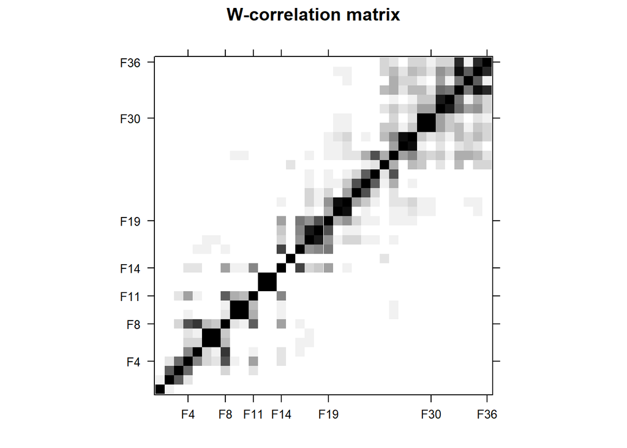

```r
plot(wcor(Women.ssa.short, groups = 1:36),
          scales = list(at = c(4,8, 11,14,19, 30,36)))
```

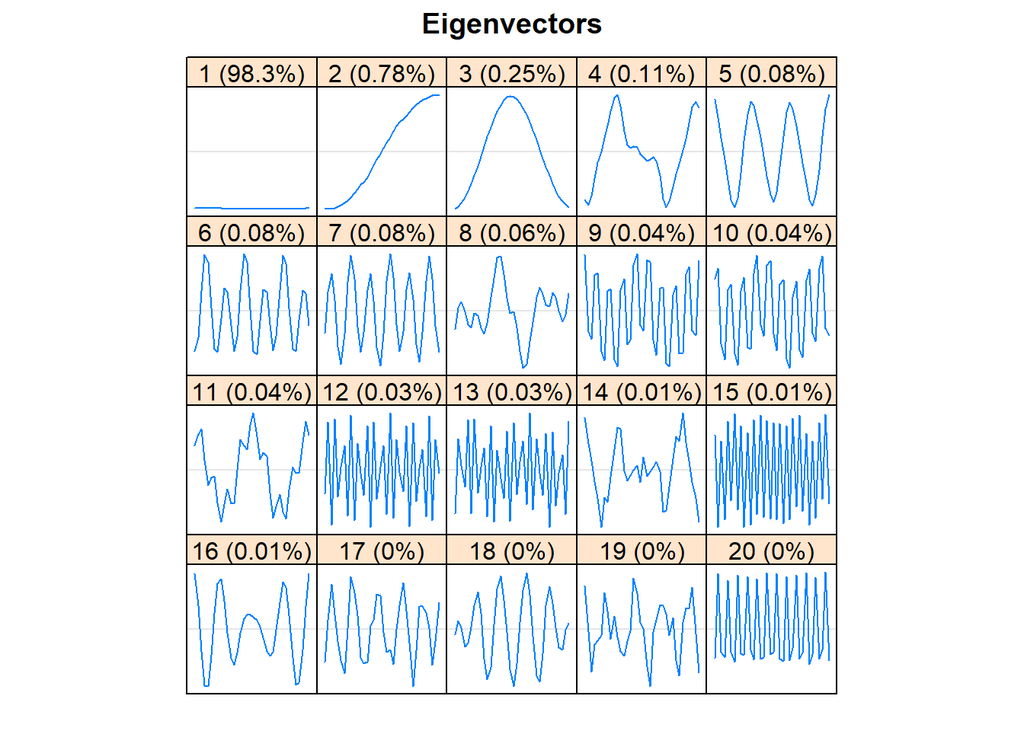

```r
plot(Women.ssa.short, type="vectors",idx=1:20)
```

Первые 4 компоненты можно причилить к тренду (отчасти смешавшимся с периодикой, но сейчас это не так важно, важно понять, какие копоненты обязательно надо взять). Возможно, 8, 11 и 14 компоненты. 15я компонента, выделяющаяся на матрице взвешенных корреляций, – это, видимо, пила. Возможно, к тренду можно отнести еще 19ю компоненту.

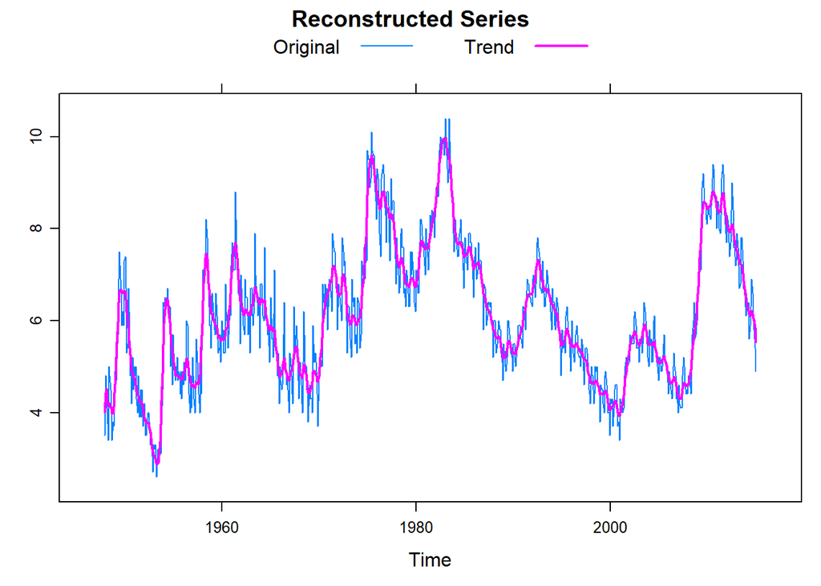

```r
r<-reconstruct(Women.ssa.short, groups = list(Trend=c(1:4,8,14,11,19)))
plot(r, plot.method = "xyplot",
     add.residuals = FALSE, add.original = TRUE,
      superpose = TRUE, auto.key = list(columns = 2),lwd=c(1,2))
```

Пора добавлять сезонность.

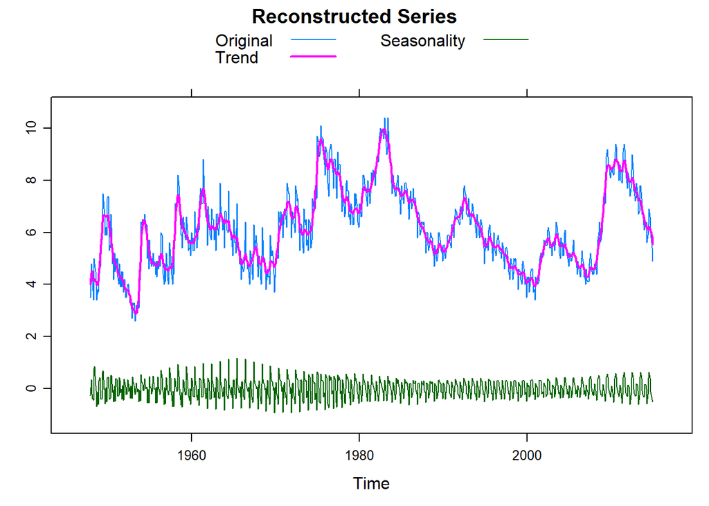

```r
r<-reconstruct(Women.ssa.short, groups = list(Trend=c(1:4,8,14,11,19),Seasonality=c(5,6,7,9,10,12,13,15)))
plot(r, plot.method = "xyplot",
     add.residuals = FALSE, add.original = TRUE,
      superpose = TRUE, auto.key = list(columns = 2),lwd=c(1,2))
```

Cезонность выглядит даже правдоподобно (несмотря на то, что мы очень условно разделяли ее с трендом). Смотрим так, потому что для данного ряда это привычнее, чем оценивать хорошесть тренда + сезонности в сумме.

## 2.1 Рекуррентный способ

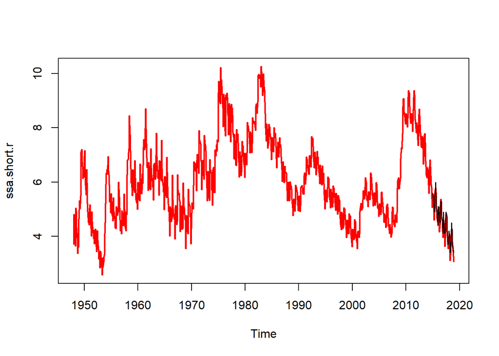

```r
ssa.short.r<-rforecast(Women.ssa.short,only.new = FALSE,groups = list(c(1:14,19)),len=length(Women.test))
plot(ssa.short.r,col='red',lwd=2)
lines(Women.test,lwd=1)
```

Очень даже неплохо! Все компоненты тренда, которые мы выбрали – необходимы. Без 14 или 19 предсказаниеповорачивается на 90 градусов.

С интервалом для предсказания:

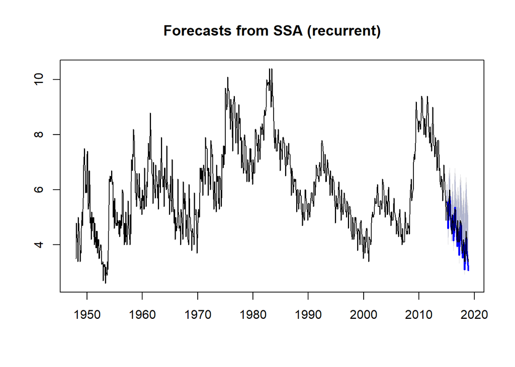

```r
set.seed(2)
rfor.prediction <- forecast::forecast(Women.ssa.short, groups = list(c(1:14,19)),
                 method = "recurrent", interval = "prediction",
                 only.intervals = TRUE,
                 len = length(Women.test), level = c(0.80,0.95))
plot(rfor.prediction)
lines(Women.test)
```

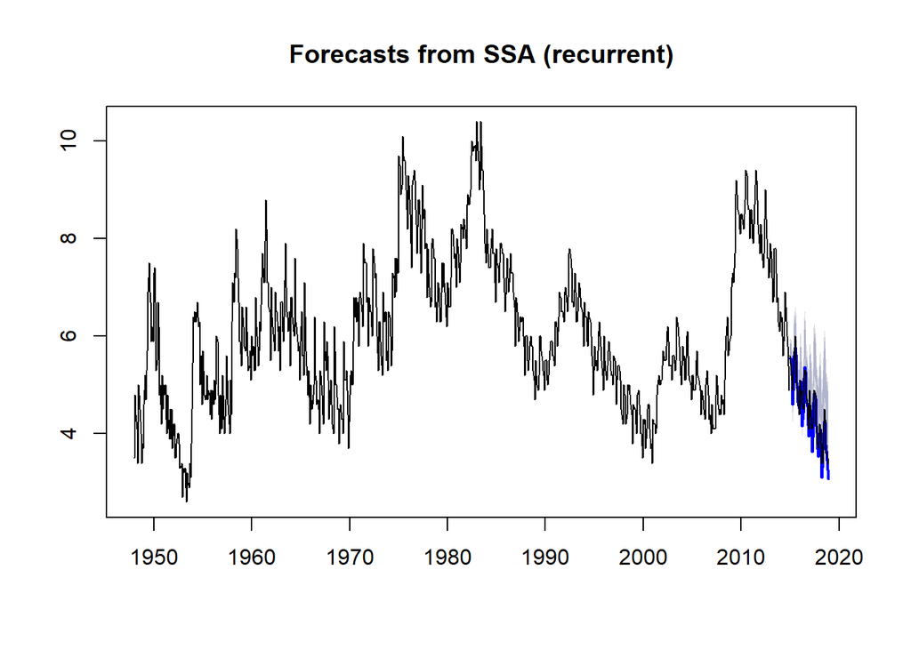

```r
rfor.prediction <- forecast::forecast(Women.ssa.short, groups = list(c(1:14,19)),
                 method = "recurrent", interval = "confidence",
                 only.intervals = TRUE,
                 len = length(Women.test), level = c(0.80,0.95))
plot(rfor.prediction)
lines(Women.test)
```

Ошибка:

```r
err.rssa<-(rfor.prediction$mean - Women.test)^2
print(c("rssa", sqrt(mean(err.rssa))))
```

```
## [1] "rssa"              "0.196072241275859"
```

## 2.2 Векторный способ

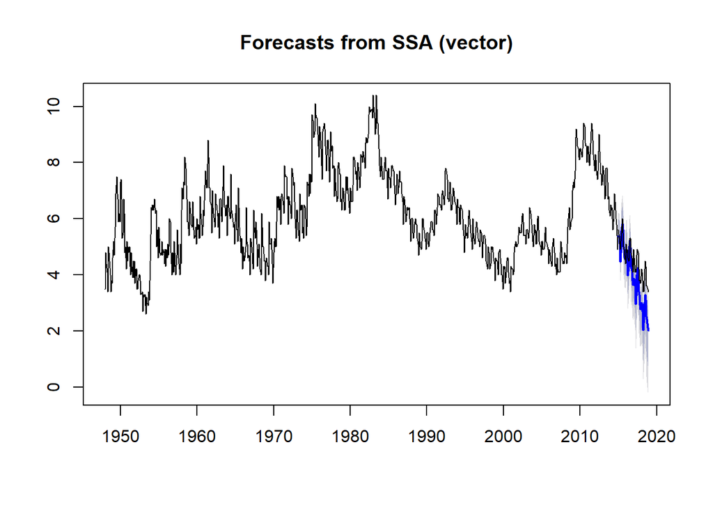

```r
set.seed(1)
vfor.prediction <- forecast::forecast(Women.ssa.short, groups = list(c(1:7,8,9:10,14,19,11,12:13)),
                 method = "vector", interval = "prediction",
                 only.intervals = TRUE,bootstrap = TRUE,
                 len = length(Women.test), level = c(0.80,0.95))
plot(vfor.prediction)
lines(Women.test)
```

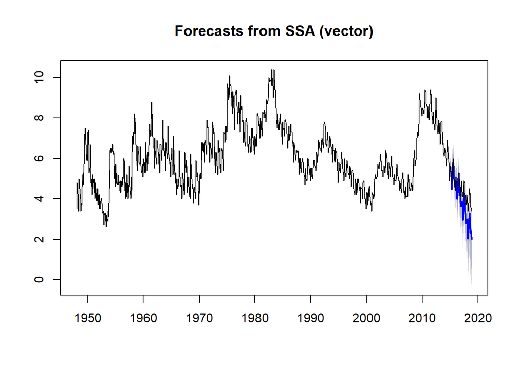

```r
vfor.prediction <- forecast::forecast(Women.ssa.short, groups = list(c(1:7,8,9:10,14,19,11,12:13)),
                 method = "vector", interval = "confidence",
                 only.intervals = TRUE,bootstrap = TRUE,
                 len = length(Women.test), level = c(0.80,0.95))
plot(vfor.prediction)
lines(Women.test)
```

Ошибка:

```r
err.vssa<-(vfor.prediction$mean - Women.test)^2
print(c("vssa", sqrt(mean(err.vssa))))
```

```
## [1] "vssa"              "0.763716536716703"
```

Тут почему-то становится лучше, если не включать 12:13 компоненты. Но если их не включать, бутстрап-интервал уползает вверх.

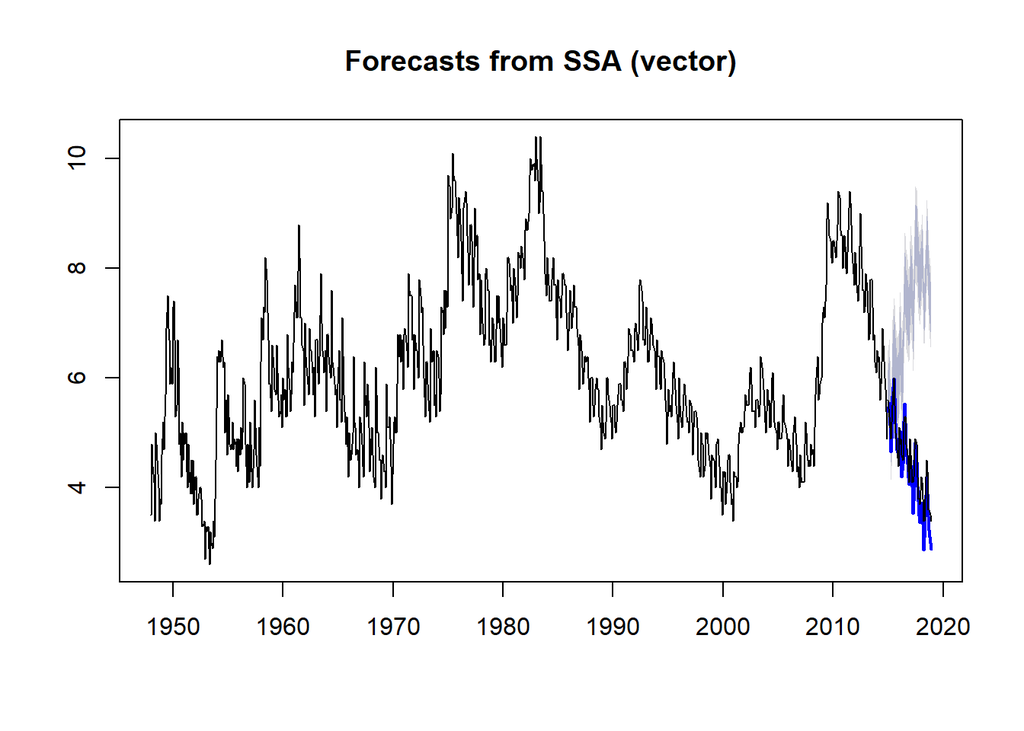

```r
set.seed(1)
vfor.prediction <- forecast::forecast(Women.ssa.short, groups = list(c(1:7,8,9:10,14,19,11)),
                 method = "vector", interval = "prediction",
                 only.intervals = TRUE,bootstrap = TRUE,
                 len = length(Women.test), level = c(0.80,0.95))
plot(vfor.prediction)
lines(Women.test)
```

Ошибка без компонент 12-13:

```r
err.vssa<-(vfor.prediction$mean - Women.test)^2
print(c("vssa", sqrt(mean(err.vssa))))
```

```
## [1] "vssa"              "0.302100020087376"
```

# 3 ETS

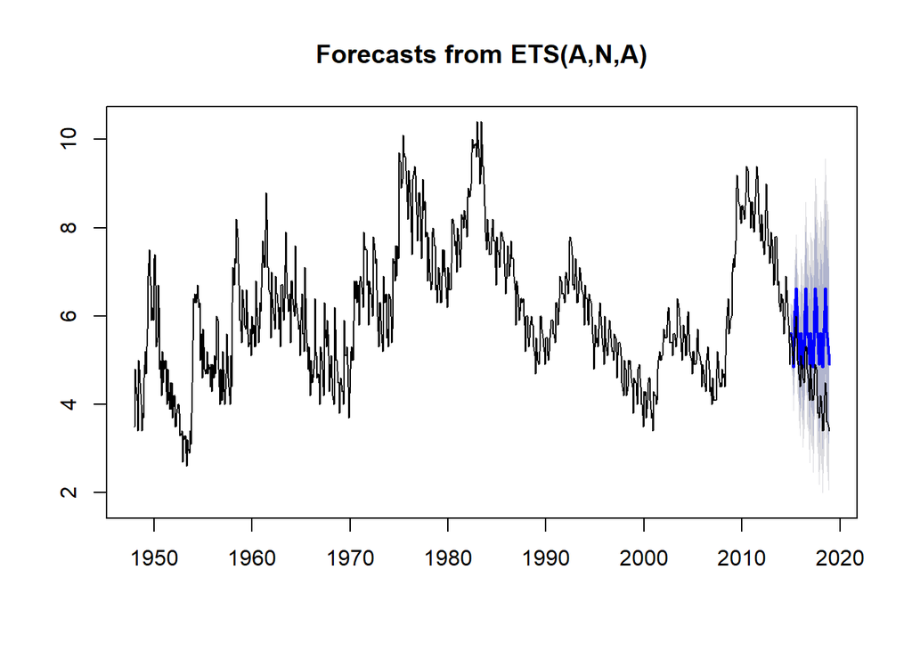

```r
fit.ets<-ets(Women.train,allow.multiplicative.trend = TRUE,opt.crit = "amse",biasadj = TRUE)
fir.ets<-ets(Women.train,model="AAA",allow.multiplicative.trend = TRUE,opt.crit = "amse",biasadj = TRUE)
for.ets<-forecast::forecast(fit.ets,len= length(Women.test),h=length(Women.test))
plot(for.ets)
lines(Women.test)
```

# 4 Сравнение

```r
err.arima<-(for.arima$mean - Women.test)^2
err.ets<-(for.ets$mean - Women.test)^2
print(c("rssa", sqrt(mean(err.rssa))))
```

```
## [1] "rssa"              "0.196072241275859"
```

```r
print(c("vssa", sqrt(mean(err.vssa))))
```

```
## [1] "vssa"              "0.302100020087376"
```

```r
print(c("sarima", sqrt(mean(err.arima))))
```

```
## [1] "sarima"           "1.15883115357653"
```

```r
print(c("ets", sqrt(mean(err.ets))))
```

```
## [1] "ets"              "1.18222863826375"
```

RMSE меньше всего для рекуррентного метода на основе SSA.

Все вышеиспользованные методы, кроме методов, основанных на SSA, неплохо отражают сезонность, но совсем не отражают тренд.  
В SSA можно достигнуть правдоподобного результата для нашего ряда, уделив особое внимание выделению тренда. Однако этот результат неустойчив: бутстрап-интервал в одном из случаев уходил вообще в другую сторону, к тому же при добавлении/удалении одной компоненты из предполагаемого сигнала предсазание может непредсказуемо развернуться.